# 12 · Q4 Pulse 3: pilot of the conversation path codebook

Do 3 independent coders read the path rules the same way?

Denicia Aragon Espinosa

November 05, 2026

# What a pilot is, and why we run one

In step 11 we wrote rules (a **codebook**) for two columns of the flow chart:

- **Column 2:** what the person did in their 2nd message.
- **Column 3:** when they first shared background information.

Before using these rules on every chat, we test them on a small sample. This test is called a **pilot**. It tells us whether the rules are clear enough that different coders reach the same answer, and where they hesitate.

Column 1 (the opening request) is already final from step 10, so it is not part of this pilot.

> **Nothing is frozen or applied here.** The suggested rule changes at the end are proposals for you to decide on.

# How the pilot was done

1. **Sample.** We picked **12 chats** with a fixed random seed (12012), so the choice can be repeated.
   - Every opening group, every column-2 label and every column-3 label appears at least once.
   - The rest are **close calls** flagged in step 11.
   - Chats that **stopped after one message** were left out. There is no 2nd message to judge, and the computer finds them on its own.
2. **Coders.** 3 fresh, independent coders each got the codebook and the full de-identified conversations.
   - Each coder saw the chats in a **different shuffled order**, with its own seed.
   - They never saw the step-11 draft labels.
3. **What each coder recorded** for every label:
   - an exact quote from the participant’s message;
   - how sure they were (high, medium or low);
   - an “unclear because…” note when the rules did not decide the case.

```r
sample |>
  select(`#` = pilot_order, Chat = chat_id, `Opening request` = col1, `Why chosen` = why_chosen) |>
  gt()
```

| # | Chat | Opening request | Why chosen |
| --- | --- | --- | --- |
| 1 | 69ab73e1 | Asking what to do | covers Asking what to do, D4, M2 |
| 2 | 6a106089 | Asking to understand | covers Asking to understand, D1, M3 |
| 3 | 6929d658 | Just sharing information | covers Just sharing information, M6 |
| 4 | 66c0f464 | Asking to understand | covers M1 |
| 5 | 6a24b2df | Asking what to do | covers D3 |
| 6 | 5f47f200 | Asking to understand | covers D2 |
| 7 | 5eec8774 | Asking what to do | covers M4 |
| 8 | 6ae359af | Asking to understand | close call |
| 9 | 5aeeb490 | Asking to understand | close call |
| 10 | 6acb95ac | Asking to understand | close call |
| 11 | 671a8337 | Just sharing information | close call |
| 12 | 6785ddfb | Asking to understand | close call |

# Did the quotes check out?

Each quote was compared word for word with the message the coder named.

**51 of 51 quotes matched exactly.** So the coders were reading the real text, not inventing it.

# Did the 3 coders agree?

**Kappa** (κ) is a score for agreement that allows for lucky guesses: 1 means perfect agreement, and 0 means no better than chance.

With only 12 chats, κ is a rough guide. One different answer would move it a lot.

```r
agree |>
  mutate(fleiss_kappa = ifelse(is.na(fleiss_kappa) | fleiss_kappa == "", "–", as.character(fleiss_kappa))) |>
  select(`What was coded` = what, Chats = chats, `All 3 agree` = all_3_agree,
         `% all 3 agree` = pct_all_3, `κ` = fleiss_kappa) |>
  gt()
```

| What was coded | Chats | All 3 agree | % all 3 agree | κ |
| --- | --- | --- | --- | --- |
| 2nd message turn | 12 | 12 | 100 | – |
| Column 2 label | 12 | 12 | 100 | 1 |
| Column 3 label (none = not coded) | 12 | 12 | 100 | 1 |
| Column 3 turn | 12 | 12 | 100 | – |

**The 3 coders agreed on every chat:** the same 2nd message, the same column-2 label, the same column-3 label and the same turn. This shows that the labels themselves are clear.

# How sure were they?

Agreement is not the whole story. The coders were **sure about column 2**, but often only **medium** or **low** for column 3. That means the column-3 rules work, but some edges need clearer wording.

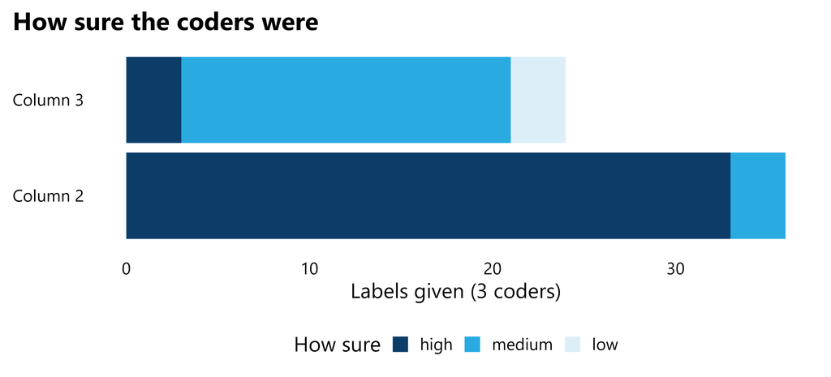

```r
conf <- bind_rows(
  codes |> filter(col2_confidence != "") |> transmute(Column = "Column 2", conf = col2_confidence),
  codes |> filter(col3_confidence != "") |> transmute(Column = "Column 3", conf = col3_confidence)
) |>
  mutate(conf = factor(conf, levels = c("high", "medium", "low"))) |>
  count(Column, conf)
p <- ggplot(conf, aes(n, Column, fill = conf)) +
  geom_col(position = position_stack(reverse = TRUE)) +
  scale_fill_manual(values = c(high = project_colors[["teal"]], medium = project_colors[["clay"]],
                               low = project_colors[["sand"]]), name = "How sure") +
  labs(title = "How sure the coders were", x = "Labels given (3 coders)", y = NULL)
save_fig("12_pilot_confidence", p, width = 11, height = 5)
p
```

# Pilot labels compared with the step-11 draft

The **pilot label** is the label at least 2 of the 3 coders gave. Here it is always all 3.

```r
vs |>
  mutate(`Column 2 same as draft` = ifelse(col2_matches_draft, "yes", "NO"),
         `Column 3 same as draft` = ifelse(col3_matches_draft, "yes", "NO")) |>
  select(Chat = chat_id, `Column 2 (pilot)` = col2_name_pilot, `Column 2 same as draft`,
         `Column 3 (pilot)` = col3_name_pilot, `Column 3 same as draft`) |>
  gt()
```

| Chat | Column 2 (pilot) | Column 2 same as draft | Column 3 (pilot) | Column 3 same as draft |
| --- | --- | --- | --- | --- |
| 69ab73e1 | Then asked what to do | yes | Never shared | yes |
| 6a106089 | Shared more about themselves | yes | With the first message | yes |
| 6929d658 | Continued a task | yes |  | yes |
| 66c0f464 | Kept asking to understand | yes |  | yes |
| 6a24b2df | Shared more about themselves | yes | After the AI asked | NO |
| 5f47f200 | Shared more about themselves | yes | After the AI asked | yes |
| 5eec8774 | Pushed back or questioned the AI | yes |  | yes |
| 6ae359af | Kept asking to understand | yes |  | yes |
| 5aeeb490 | Shared more about themselves | yes | After the AI asked | yes |
| 6acb95ac | Shared more about themselves | yes | Never shared | yes |
| 671a8337 | Then asked what to do | yes | On their own later | NO |
| 6785ddfb | Shared more about themselves | yes | Never shared | yes |

**Column 2 matched the draft for all 12 chats.** Column 3 differed for 2 chats:

- **6a24b2df** (weight-loss plan): the coders said **After the AI asked**; the draft said On their own later. **The coders were right.** The AI had asked for the current weight in a form, with no question mark, and the draft missed it. You approved fixing the draft (P9); it is now After the AI asked.
- **671a8337** (“what if i am spitting blood”): the coders said **On their own later**; the draft said Never shared. The difference is whether a “what if” symptom counts as background. **You decided a “what if” symptom is not background** (P2), so it stays Never shared.

# Where the coders hesitated

These are the coders’ own “unclear because…” notes, grouped by chat.

```r
unclear |>
  select(Chat = chat_id, Column = column, Coder = coder, Label = code, Note = note) |>
  gt(groupname_col = "Chat")
```

| Column | Coder | Label | Note |
| --- | --- | --- | --- |
| 5aeeb490 |  |  |  |
| column 3 | 1 | D2 | unclear because 'After sleeping' (how it started) may be a recent event that led up to the problem, or just description of onset; if not background, the first background would be the other symptom 'He… |
| column 3 | 2 | D2 | unclear because 'After sleeping' (how it started, answering 'How did it start?') may be read as a recent event leading up to it; if not, first background is the other symptom 'Headache' in human_7, al… |
| column 3 | 3 | D2 | unclear because it is not certain that 'After sleeping' counts as a recent event that led up to the problem rather than a description of the main problem; if not, the first background is 'Headache' (o… |
| 5f47f200 |  |  |  |
| column 3 | 1 | D2 | unclear because running daily is an activity that may have led up to the problem; the AI asked about how it started and swelling, so it was coded D2 per the 'different, unrequested background' rule; c… |
| column 3 | 2 | D2 | unclear because daily running is a recent activity that may have led up to the pain; the AI asked about onset and swelling, not running, but the codebook says unrequested background after an AI questi… |
| column 3 | 3 | D2 | unclear because daily running is an ongoing activity rather than a single recent event; treated like 'after travel with lots of walking'. The AI asked how it started, so D2. |
| 66c0f464 |  |  |  |
| column 2 | 1 | M1 | unclear because the question is posed as a survey-style question to the AI rather than about the participant's own health; it asks about effects (general facts), so M1; considered that it may not be a… |
| column 2 | 2 | M1 | unclear because the question asks the AI about its own experience (survey-style), not about the participant; it fits 'general facts' (M1) best, no other code fits better. |
| column 2 | 3 | M1 | unclear because the participant appears to be feeding survey items to the AI rather than asking about their own health; M6 (continued a task) was considered. |
| 671a8337 |  |  |  |
| column 3 | 1 | D3 | unclear because it is phrased as a hypothetical 'what if' question, so it is not clear the participant actually has this other symptom; ai_1 asked no question about them, so D3 rather than D2; conside… |
| column 3 | 2 | D3 | unclear because 'when running' in the first message could be read as an event leading up to the pain (D1), but I read it as describing the main complaint; spitting blood is an other symptom, phrased a… |
| column 3 | 3 | D3 | unclear because spitting blood would be another symptom, but it is phrased as a hypothetical 'what if'; D4 was considered. The AI turn before asked no question, so D3 rather than D2. |
| 6785ddfb |  |  |  |
| column 3 | 1 | D4 | unclear because 'itching and bumps all over' could be read as other symptoms (background), but it appears to describe the main problem (suspected hives) in more detail; considered D2. |
| column 3 | 2 | D4 | unclear because itching and bumps all over describe the main problem (possible hives) rather than background; could be read as 'other symptoms' (D2, answering the AI's question). human_3 is thanks-onl… |
| column 3 | 3 | D4 | unclear because itching and bumps all over could be read as other symptoms (D2) but they are the main complaint (hives) described in more detail. |
| 69ab73e1 |  |  |  |
| column 3 | 1 | D4 | unclear because the participant answered the AI's question about other symptoms with 'none'; location and cramping describe the main problem, so no background was shared, but D2 was considered. |
| column 3 | 2 | D4 | unclear because human_2 says 'my other symptoms are none'; other symptoms count as background but stating there are none adds no background, and location/cramping feel is description of the main probl… |
| column 3 | 3 | D4 | unclear because human_2 only gives location and feel of the pain and says other symptoms are none; saying there are no other symptoms was not treated as background. |
| 6a24b2df |  |  |  |
| column 3 | 1 | D2 | unclear because the codebook does not list weight explicitly as background; it was treated like age/health history; the AI asked for current weight just before. Considered D4. |
| column 3 | 2 | D2 | unclear because current weight is not explicitly listed as background (closest to age/health history); it answers the AI's request to confirm current weight. Considered D4 if weight is treated as part… |
| column 3 | 3 | D2 | unclear because current weight is not explicitly listed as background information; it answers the AI's request for current weight. If weight is not background, the next candidate is 'mostly sedentary'… |
| 6acb95ac |  |  |  |
| column 2 | 1 | M3 | unclear because the turn begins with 'Convert to PDF', which the codebook lists as thanks-only on its own; here it is followed by real information, so it was treated as the 2nd message. |
| column 2 | 3 | M3 | unclear because the turn begins with 'Convert to PDF', which is listed as thanks-only, but the rest of the turn answers the AI's questions, so it was treated as a real message. |
| column 3 | 1 | D4 | unclear because the first message says the spots last 'a few days or weeks' and then disappear, which could be read as duration (background), but it describes the pattern of the main problem; consider… |
| column 3 | 2 | D4 | unclear because the first message says the spots are 'only there for a few days or weeks and then randomly disappear', which could be read as how long the problem has been going on (D1); I read it as … |
| column 3 | 3 | D4 | unclear because the first message says the spots are 'only there for a few days or weeks and then randomly disappear', which could count as how long the problem has been going on (D1); I treated it as… |

# Proposed rule changes (your decisions)

These were proposals from the pilot. **You approved all 9**, and they have been applied to the step 11 codebook (decisions L16 to L24). Most only make the wording clearer. P9 changed one draft label (6a24b2df), and P2 confirmed another (671a8337 stays Never shared).

```r
edits |>
  select(ID = id, Area = area, `Proposed wording` = proposed_wording, Why = why,
         `Effect on labels` = effect_on_labels, Status = status) |>
  gt() |>
  cols_width(ID ~ px(50))
```

| ID | Area | Proposed wording | Why | Effect on labels | Status |
| --- | --- | --- | --- | --- | --- |
| P1 | column 3: background list | Add body weight, height, activity level and regular habits (for example 'I run daily', 'mostly sedentary') to the list of background information. | All 3 coders were unsure whether weight (6a24b2df) and daily running (5f47f200) count; they used D2 but marked it unclear. | No label change in the pilot (all 3 already treated them as background). | applied: approved by analyst 2026-11-05 (log L16) |
| P2 | column 3: 'what if' symptoms | A symptom asked about as a 'what if' (not said to be happening) is NOT background information. | 671a8337 'what if i am spitting blood': all 3 coders coded D3 (On their own later) but were unsure; the draft had D4. | 671a8337 would be D4 Never shared (as drafted). If you prefer the coders' reading, it stays D3. | applied: approved by analyst 2026-11-05 (log L17) |
| P3 | column 3: how it started | Something that happened BEFORE the problem started ('after travel', 'after sleeping', 'after the shots') is background. The activity during which the symptom shows up ('chest pain when running', 'hurt… | Coders were unsure about 'After sleeping' (5aeeb490) and 'when running' (671a8337). | 5aeeb490 stays D2 (first background at human_4 'After sleeping' instead of human_7 'Headache'). 671a8337 unchanged. | applied: approved by analyst 2026-11-05 (log L18) |
| P4 | column 3: 'no' answers | Saying there is NO other symptom or no swelling is not background information. | Coders raised it for 69ab73e1 ('my other symptoms are none') and 5f47f200 ('There is no swelling'). | No label change. | applied: approved by analyst 2026-11-05 (log L19) |
| P5 | column 3: how long | 'How long it has been going on' means how long the problem has existed overall (for example 'for the past few weeks'). How long each flare or episode lasts is description of the main problem. | 6acb95ac 'only there for a few days or weeks and then randomly disappear': all 3 coded D4 but were unsure. | No label change. | applied: approved by analyst 2026-11-05 (log L20) |
| P6 | column 3: other symptoms | An 'other symptom' is one beyond the problem the person is asking about (for example a headache alongside neck pain). Symptoms that are part of the problem they asked about (itching and bumps when ask… | 6785ddfb and 5aeeb490: coders asked where the line is. | No label change. | applied: approved by analyst 2026-11-05 (log L21) |
| P7 | column 2: mixed thanks fragments | If a turn starts with a thanks or task fragment ('Convert to PDF') but then gives real content, ignore the fragment and code the rest. | 6acb95ac: 2 of 3 coders asked for this rule (they did it anyway). | No label change. | applied: approved by analyst 2026-11-05 (log L22) |
| P8 | column 2: questions to the AI about itself | A question that asks the AI about its own experience or opinion (for example survey-style questions) is coded M1 Kept asking to understand. | 66c0f464: all 3 coders used M1 but were unsure (M6 considered). | No label change. | applied: approved by analyst 2026-11-05 (log L23) |
| P9 | draft label fix | 6a24b2df column 3: change the draft from D3 to D2. The AI did ask for the current weight just before (in a form, without a question mark), so the coders were right. | Found by the pilot; the draft had missed the AI's form-style question. | 6a24b2df D3 -> D2 in the draft labels (On their own later 3 -> 2, After the AI asked 5 -> 6). | applied: approved by analyst 2026-11-05 (log L24) |

# Optional: code the 12 chats yourself

`12_hand-coding_sheet.xlsx` lists the 12 pilot chats.

- The **conversations** tab has the full chats.
- The **hand_coding** tab has drop-down lists for column 2 and column 3.
- The **definitions** tab has the rules.

This is optional. If you fill it in, we can compare your labels with the coders’.

# Files

- `scripts\12_pilot-path-codebook\`:
  - `12a_prepare_pilot.py` (sample, codebook text, coder inputs);
  - `12b_check_pilot.py` (checks);
  - `prompts\`;
  - this report.
- `output\12_pilot-path-codebook\`:
  - `12_Q4_3_path-pilot_results.xlsx` (all results in one workbook);
  - `12_proposed_edits.csv`;
  - `12_hand-coding_sheet.xlsx`;
  - `pilot_*.csv`;
  - `input\` (sample, shuffled inputs, seeds);
  - `codebook\pilot_path_codebook.md` (exactly what the coders saw);
  - `coders\` (prompts and raw outputs).